# ML_HW4_mn2984

Ming Nie mn2984

The work is done in Google Colab and transfered to HTML using jupyter notebook.

Part 1:

```python
#Import Python Libraries
import numpy as np
import scipy as sp
import pandas as pd
import matplotlib as mpl
import seaborn as sns
import statistics
import matplotlib.pyplot as plt
```

```python
from google.colab import files
uploaded = files.upload()
```

Upload widget is only available when the cell has been executed in the current browser session. Please rerun this cell to enable.

```
Saving HW4_Text_test_data.csv to HW4_Text_test_data (1).csv
Saving HW4_Text_train_data.csv to HW4_Text_train_data (1).csv
```

```python
import io
train = pd.read_csv(io.BytesIO(uploaded['HW4_Text_train_data.csv']))
train.head()
```

|  | Review | Recommended |
| --- | --- | --- |
| 0 | "go to" please offer a maxi for mature custome... | 1 |
| 1 | "go to" tee for sz 10+ women.Women who want so... | 1 |
| 2 | "long and warm".These leg warmers are perfect ... | 1 |
| 3 | "tweed" dress.I bought this dress for my siste... | 1 |
| 4 | #1 stunna.I am in lust with this fabulous dres... | 1 |

```python
test = pd.read_csv(io.BytesIO(uploaded['HW4_Text_test_data.csv']))
test.head()
```

|  | Review | Recommended |
| --- | --- | --- |
| 0 | "beach business".Great for the beachy business... | 1 |
| 1 | "formal pajamas".These are super comfy and so ... | 1 |
| 2 | "perfect with jeans".Great with leggings.perfe... | 1 |
| 3 | "won't stretch" tags are misleading.The tag on... | 1 |
| 4 | $200 piece of polyester.A $200 piece of polyes... | 0 |

```python
from sklearn.feature_extraction.text import CountVectorizer

text_train = train['Review']
y_train = train['Recommended']

text_test = test['Review']
y_test = test['Recommended']
```

```python
from sklearn.model_selection import cross_val_score
from sklearn.model_selection import KFold
kfold = KFold(n_splits=5)
from sklearn.metrics import classification_report
```

```python
# helper function to plot top positive and negative coefficients

def visualize_coefficients(coefficients, feature_names, n_top_features=25):
    """Visualize coefficients of a linear model.
    Parameters
    ----------
    coefficients : nd-array, shape (n_features,)
        Model coefficients.
    feature_names : list or nd-array of strings, shape (n_features,)
        Feature names for labeling the coefficients.
    n_top_features : int, default=25
        How many features to show. The function will show the largest (most
        positive) and smallest (most negative)  n_top_features coefficients,
        for a total of 2 * n_top_features coefficients.
    """
    coefficients = coefficients.squeeze()
    if coefficients.ndim > 1:
        # this is not a row or column vector
        raise ValueError("coeffients must be 1d array or column vector, got"
                         " shape {}".format(coefficients.shape))
    coefficients = coefficients.ravel()

    if len(coefficients) != len(feature_names):
        raise ValueError("Number of coefficients {} doesn't match number of"
                         "feature names {}.".format(len(coefficients),
                                                    len(feature_names)))
    # get coefficients with large absolute values
    coef = coefficients.ravel()
    positive_coefficients = np.argsort(coef)[-n_top_features:]
    negative_coefficients = np.argsort(coef)[:n_top_features]
    interesting_coefficients = np.hstack([negative_coefficients,
                                          positive_coefficients])
    # plot them
    plt.figure(figsize=(15, 5))
    colors = ['#ff2020' if c < 0 else '#0000aa'
              for c in coef[interesting_coefficients]]
    plt.bar(np.arange(2 * n_top_features), coef[interesting_coefficients],
            color=colors)
    feature_names = np.array(feature_names)
    plt.subplots_adjust(bottom=0.3)
    plt.xticks(np.arange(1, 1 + 2 * n_top_features),
               feature_names[interesting_coefficients], rotation=60,
               ha="right")
    plt.ylabel("Coefficient magnitude")
    plt.xlabel("Feature")
```

```python
# vectorize 1
vect1 = CountVectorizer().fit(text_train)
X_train = vect1.transform(text_train)
print("X_train:\n{}".format(repr(X_train)))
X_test = vect1.transform(text_test)
print("X_test:\n{}".format(repr(X_test)))
```

```
X_train:
<16985x13010 sparse matrix of type '<class 'numpy.int64'>'
	with 749166 stored elements in Compressed Sparse Row format>
X_test:
<5657x13010 sparse matrix of type '<class 'numpy.int64'>'
	with 248933 stored elements in Compressed Sparse Row format>
```

```python
#Logistic Regression 1
from sklearn.model_selection import cross_val_score
from sklearn.linear_model import LogisticRegression
from sklearn.model_selection import GridSearchCV

param_grid = {'C': [0.001, 0.01, 0.1, 1, 10]}
grid = GridSearchCV(LogisticRegression( max_iter=100000), param_grid, cv=5)
grid.fit(X_train, y_train)
print("Best cross-validation score: {:.2f}".format(grid.best_score_))
print("Test score: {:.2f}".format(grid.score(X_test, y_test)))

y_pred = grid.predict(X_test)
print(classification_report(y_test, y_pred))
print("the best one: {}".format(grid.best_estimator_))
```

```
Best cross-validation score: 0.90
Test score: 0.90
              precision    recall  f1-score   support

           0       0.75      0.66      0.70      1026
           1       0.93      0.95      0.94      4631

    accuracy                           0.90      5657
   macro avg       0.84      0.80      0.82      5657
weighted avg       0.90      0.90      0.90      5657

the best one: LogisticRegression(C=0.1, class_weight=None, dual=False, fit_intercept=True,
                   intercept_scaling=1, l1_ratio=None, max_iter=100000,
                   multi_class='auto', n_jobs=None, penalty='l2',
                   random_state=None, solver='lbfgs', tol=0.0001, verbose=0,
                   warm_start=False)
```

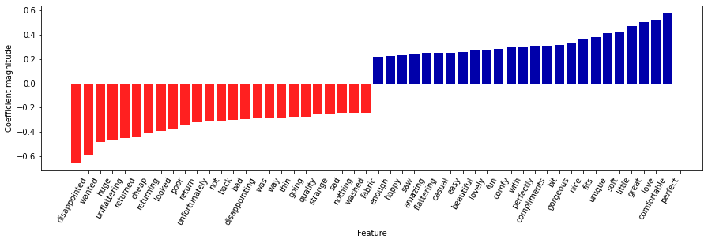

```python
coefs1 = LogisticRegression(C=0.1).fit(X_train,y_train).coef_
feature_names1 = vect1.get_feature_names()
visualize_coefficients(coefs1, feature_names1, n_top_features=25)
```

```python
# vectorize 2 use english stop words
vect2 = CountVectorizer(stop_words='english').fit(text_train)
X_train = vect.transform(text_train)
print("X_train:\n{}".format(repr(X_train)))
X_test = vect.transform(text_test)
print("X_test:\n{}".format(repr(X_test)))
```

```
X_train:
<16985x12727 sparse matrix of type '<class 'numpy.int64'>'
	with 419265 stored elements in Compressed Sparse Row format>
X_test:
<5657x12727 sparse matrix of type '<class 'numpy.int64'>'
	with 138342 stored elements in Compressed Sparse Row format>
```

```python
#Logistic Regression 2
grid2 = GridSearchCV(LogisticRegression( max_iter=100000), param_grid, cv=5)
grid2.fit(X_train, y_train)
print("Best cross-validation score: {:.2f}".format(grid2.best_score_))
print("Test score: {:.2f}".format(grid2.score(X_test, y_test)))

y_pred = grid2.predict(X_test)
print(classification_report(y_test, y_pred))
print("the best one: {}".format(grid2.best_estimator_))
```

```
Best cross-validation score: 0.89
Test score: 0.89
              precision    recall  f1-score   support

           0       0.76      0.61      0.68      1026
           1       0.92      0.96      0.94      4631

    accuracy                           0.89      5657
   macro avg       0.84      0.79      0.81      5657
weighted avg       0.89      0.89      0.89      5657

the best one: LogisticRegression(C=0.1, class_weight=None, dual=False, fit_intercept=True,
                   intercept_scaling=1, l1_ratio=None, max_iter=100000,
                   multi_class='auto', n_jobs=None, penalty='l2',
                   random_state=None, solver='lbfgs', tol=0.0001, verbose=0,
                   warm_start=False)
```

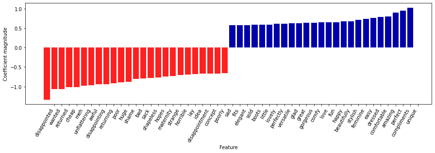

```python
coefs2 = LogisticRegression(C=0.1).fit(X_train,y_train).coef_
feature_names2 = vect2.get_feature_names()
visualize_coefficients(coefs2, feature_names2, n_top_features=25)
```

```python
coef_svm = svm.coef_
feature_name_svm = vect.get_feature_names()
visualize_coefficients(coef_svm, feature_name_svm, n_top_features=25)
```

[output not shown]

```python
# vectorize 3 TF-IDF vectorizer
from sklearn.feature_extraction.text import TfidfVectorizer
vect3 = TfidfVectorizer(min_df=5, norm=None).fit(text_train)
X_train = vect3.transform(text_train)
print("X_train:\n{}".format(repr(X_train)))
X_test = vect3.transform(text_test)
print("X_test:\n{}".format(repr(X_test)))
```

```
X_train:
<16985x4396 sparse matrix of type '<class 'numpy.float64'>'
	with 735449 stored elements in Compressed Sparse Row format>
X_test:
<5657x4396 sparse matrix of type '<class 'numpy.float64'>'
	with 245539 stored elements in Compressed Sparse Row format>
```

```python
#Logistic Regression 3
grid3 = GridSearchCV(LogisticRegression( max_iter=100000), param_grid, cv=5)
grid3.fit(X_train, y_train)
print("Best cross-validation score: {:.2f}".format(grid3.best_score_))
print("Test score: {:.2f}".format(grid3.score(X_test, y_test)))

y_pred = grid3.predict(X_test)
print(classification_report(y_test, y_pred))
print("the best one: {}".format(grid3.best_estimator_))
```

```
Best cross-validation score: 0.90
Test score: 0.90
              precision    recall  f1-score   support

           0       0.74      0.67      0.70      1026
           1       0.93      0.95      0.94      4631

    accuracy                           0.90      5657
   macro avg       0.84      0.81      0.82      5657
weighted avg       0.89      0.90      0.90      5657

the best one: LogisticRegression(C=0.01, class_weight=None, dual=False, fit_intercept=True,
                   intercept_scaling=1, l1_ratio=None, max_iter=100000,
                   multi_class='auto', n_jobs=None, penalty='l2',
                   random_state=None, solver='lbfgs', tol=0.0001, verbose=0,
                   warm_start=False)
```

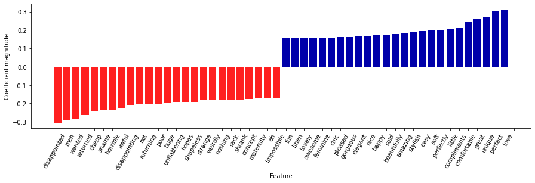

```python
coefs3 = LogisticRegression(C=0.01).fit(X_train,y_train).coef_
feature_names3 = vect3.get_feature_names()
visualize_coefficients(coefs3, feature_names3, n_top_features=25)
```

All three models did well in both cross validation score and test score. The scores are all around 0.9.

Part 2: Build a predictive neural network using Keras

```python
# fix random seed for reproducibility
seed = 7
np.random.seed(seed)

# load pimas diabetes dataset
dataset = pd.read_csv("http://vincentarelbundock.github.io/Rdatasets/csv/datasets/iris.csv" , encoding="latin_1")


dataset.head()
```

|  | Unnamed: 0 | Sepal.Length | Sepal.Width | Petal.Length | Petal.Width | Species |
| --- | --- | --- | --- | --- | --- | --- |
| 0 | 1 | 5.1 | 3.5 | 1.4 | 0.2 | setosa |
| 1 | 2 | 4.9 | 3.0 | 1.4 | 0.2 | setosa |
| 2 | 3 | 4.7 | 3.2 | 1.3 | 0.2 | setosa |
| 3 | 4 | 4.6 | 3.1 | 1.5 | 0.2 | setosa |
| 4 | 5 | 5.0 | 3.6 | 1.4 | 0.2 | setosa |

```python
# find out how many categories
dataset.Species.unique()
```

```
array(['setosa', 'versicolor', 'virginica'], dtype=object)
```

```python
y2 = pd.get_dummies(dataset['Species'])
X2 = dataset.iloc[:, 1:5]
X2.head()
```

|  | Sepal.Length | Sepal.Width | Petal.Length | Petal.Width |
| --- | --- | --- | --- | --- |
| 0 | 5.1 | 3.5 | 1.4 | 0.2 |
| 1 | 4.9 | 3.0 | 1.4 | 0.2 |
| 2 | 4.7 | 3.2 | 1.3 | 0.2 |
| 3 | 4.6 | 3.1 | 1.5 | 0.2 |
| 4 | 5.0 | 3.6 | 1.4 | 0.2 |

```python
y2.head()
```

|  | setosa | versicolor | virginica |
| --- | --- | --- | --- |
| 0 | 1 | 0 | 0 |
| 1 | 1 | 0 | 0 |
| 2 | 1 | 0 | 0 |
| 3 | 1 | 0 | 0 |
| 4 | 1 | 0 | 0 |

```python
from sklearn.model_selection import train_test_split
X2_train, X2_test, y2_train, y2_test = train_test_split(X2, y2,random_state=42)
```

```python
X2_train.head()
```

|  | Sepal.Length | Sepal.Width | Petal.Length | Petal.Width |
| --- | --- | --- | --- | --- |
| 4 | 5.0 | 3.6 | 1.4 | 0.2 |
| 32 | 5.2 | 4.1 | 1.5 | 0.1 |
| 142 | 5.8 | 2.7 | 5.1 | 1.9 |
| 85 | 6.0 | 3.4 | 4.5 | 1.6 |
| 86 | 6.7 | 3.1 | 4.7 | 1.5 |

```python
X2_test.head()
```

|  | Sepal.Length | Sepal.Width | Petal.Length | Petal.Width |
| --- | --- | --- | --- | --- |
| 73 | 6.1 | 2.8 | 4.7 | 1.2 |
| 18 | 5.7 | 3.8 | 1.7 | 0.3 |
| 118 | 7.7 | 2.6 | 6.9 | 2.3 |
| 78 | 6.0 | 2.9 | 4.5 | 1.5 |
| 76 | 6.8 | 2.8 | 4.8 | 1.4 |

```python
y2_train.head()
```

|  | setosa | versicolor | virginica |
| --- | --- | --- | --- |
| 4 | 1 | 0 | 0 |
| 32 | 1 | 0 | 0 |
| 142 | 0 | 0 | 1 |
| 85 | 0 | 1 | 0 |
| 86 | 0 | 1 | 0 |

```python
y2_test.head()
```

|  | setosa | versicolor | virginica |
| --- | --- | --- | --- |
| 73 | 0 | 1 | 0 |
| 18 | 1 | 0 | 0 |
| 118 | 0 | 0 | 1 |
| 78 | 0 | 1 | 0 |
| 76 | 0 | 1 | 0 |

```python
# 2.1 a multilayer perceptron
from tensorflow.keras.models import Sequential
from tensorflow.keras.layers import Dense, Activation

model = Sequential([
    Dense(32,input_dim=4),
    Activation('relu'),
    Dense(32),
    Activation('relu'),
    Dense(3),
    Activation('softmax'),
])


model.compile(optimizer = 'sgd',
              loss='categorical_crossentropy',
              metrics=['accuracy'])

model.fit(X2_train, y2_train, validation_split=0.20, epochs=100)
score = model.evaluate(X2_test, y2_test, batch_size=128) # extract loss and accuracy from test data evaluation
print(score)
```

```
[0.30634695291519165, 0.8947368264198303]
```

```python
# 2.2 selecting the number of hidden units using GridSearchCV
from tensorflow.keras.wrappers.scikit_learn import KerasClassifier
def create_model(units):
	# create model
	model = Sequential([
    Dense(units=units,input_dim=4),
    Activation('relu'),
    Dense(units=units),
    Activation('relu'),
    Dense(3),
    Activation('softmax'),
])
	model.compile(optimizer = 'sgd',loss='categorical_crossentropy',  metrics=['accuracy'])
	return model

model = KerasClassifier(build_fn=create_model, epochs=20, verbose=0)

units = [2,3,4,5,6,7,8,9,10]

param_grid = dict(units=units)

grid = GridSearchCV(estimator=model, param_grid=param_grid)
grid_result = grid.fit(X2_train, y2_train)

# summarize results
print("Best: %f using %s" % (grid_result.best_score_, grid_result.best_params_))
means = grid_result.cv_results_['mean_test_score']
stds = grid_result.cv_results_['std_test_score']
params = grid_result.cv_results_['params']
for mean, stdev, param in zip(means, stds, params):
    print("%f (%f) with: %r" % (mean, stdev, param))
```

[output not shown]

[output cut: 38 more lines]

```python
# the best one with 10 units
model2 = Sequential([
    Dense(10,input_dim=4),
    Activation('relu'),
    Dense(10),
    Activation('relu'),
    Dense(3),
    Activation('softmax'),
])


model2.compile(optimizer = 'sgd',
              loss='categorical_crossentropy',
              metrics=['accuracy'])

model2.fit(X2_train, y2_train, validation_split=0.20, epochs=100)
score2 = model2.evaluate(X2_test, y2_test, batch_size=128) # extract loss and accuracy from test data evaluation
print(score2)
```

```
[0.3416570723056793, 0.8947368264198303]
```

```python
model2.metrics_names
```

```
['loss', 'accuracy']
```

Describe the differences in the predictive accuracy of models with different numbers of hidden units. Describe the predictive strength of your best model. Be sure to explain your choice and evaluate this model using the test set.

Answer: In general, we will have a higher predictive accuracy with more hidden units. The best one is 10 units for my model.